# Red Wine Exploration by Darui Zhang

What property makes great red wine great? In this project we will try to answer this question by exploring the red wine data set.

```
##  [1] "X"                    "fixed.acidity"        "volatile.acidity"
##  [4] "citric.acid"          "residual.sugar"       "chlorides"
##  [7] "free.sulfur.dioxide"  "total.sulfur.dioxide" "density"
## [10] "pH"                   "sulphates"            "alcohol"
## [13] "quality"
```

# Univariate Plots Section

### Univariate Plots Selection

Feature names and summary

```
##  [1] "X"                    "fixed.acidity"        "volatile.acidity"
##  [4] "citric.acid"          "residual.sugar"       "chlorides"
##  [7] "free.sulfur.dioxide"  "total.sulfur.dioxide" "density"
## [10] "pH"                   "sulphates"            "alcohol"
## [13] "quality"
```

```
##        X          fixed.acidity   volatile.acidity  citric.acid
##  Min.   :   1.0   Min.   : 4.60   Min.   :0.1200   Min.   :0.000
##  1st Qu.: 400.5   1st Qu.: 7.10   1st Qu.:0.3900   1st Qu.:0.090
##  Median : 800.0   Median : 7.90   Median :0.5200   Median :0.260
##  Mean   : 800.0   Mean   : 8.32   Mean   :0.5278   Mean   :0.271
##  3rd Qu.:1199.5   3rd Qu.: 9.20   3rd Qu.:0.6400   3rd Qu.:0.420
##  Max.   :1599.0   Max.   :15.90   Max.   :1.5800   Max.   :1.000
##  residual.sugar     chlorides       free.sulfur.dioxide
##  Min.   : 0.900   Min.   :0.01200   Min.   : 1.00
##  1st Qu.: 1.900   1st Qu.:0.07000   1st Qu.: 7.00
##  Median : 2.200   Median :0.07900   Median :14.00
##  Mean   : 2.539   Mean   :0.08747   Mean   :15.87
##  3rd Qu.: 2.600   3rd Qu.:0.09000   3rd Qu.:21.00
##  Max.   :15.500   Max.   :0.61100   Max.   :72.00
##  total.sulfur.dioxide    density             pH          sulphates
##  Min.   :  6.00       Min.   :0.9901   Min.   :2.740   Min.   :0.3300
##  1st Qu.: 22.00       1st Qu.:0.9956   1st Qu.:3.210   1st Qu.:0.5500
##  Median : 38.00       Median :0.9968   Median :3.310   Median :0.6200
##  Mean   : 46.47       Mean   :0.9967   Mean   :3.311   Mean   :0.6581
##  3rd Qu.: 62.00       3rd Qu.:0.9978   3rd Qu.:3.400   3rd Qu.:0.7300
##  Max.   :289.00       Max.   :1.0037   Max.   :4.010   Max.   :2.0000
##     alcohol         quality
##  Min.   : 8.40   Min.   :3.000
##  1st Qu.: 9.50   1st Qu.:5.000
##  Median :10.20   Median :6.000
##  Mean   :10.42   Mean   :5.636
##  3rd Qu.:11.10   3rd Qu.:6.000
##  Max.   :14.90   Max.   :8.000
```

This tidy data set contains 1,599 red wines with 11 variables on the chemical properties of the wine.

### Wine Quality Distribution in the Dataset

The wine quality grade is a discrete number. It is ranged from 3 to 8. The median value is at 6.

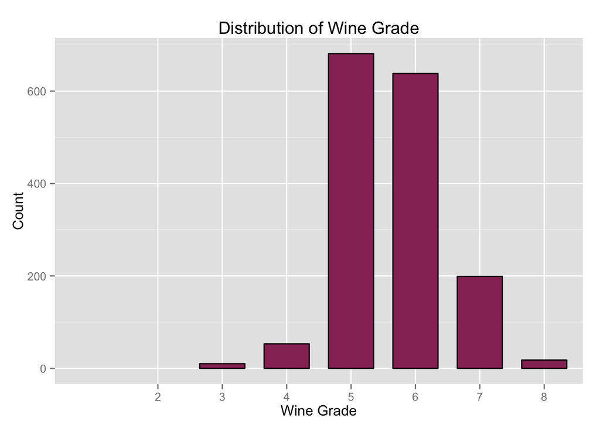

### Exploring the distribution of other chemical properties

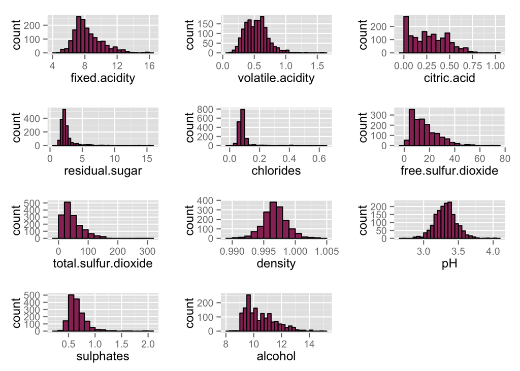

### Univariate Analysis

Some observed on the distribution of the chemical property can be made:

- **Normal**: volatile.acidity, density, PH
- **Positively Skewed**: fixed.acidity, citric.acid, free.sulfur.dioxide, total.sulfur.dioxide,sulphates,alcohol
- **Long Tail**: residual.sugar, chlorides

### Rescale Variables

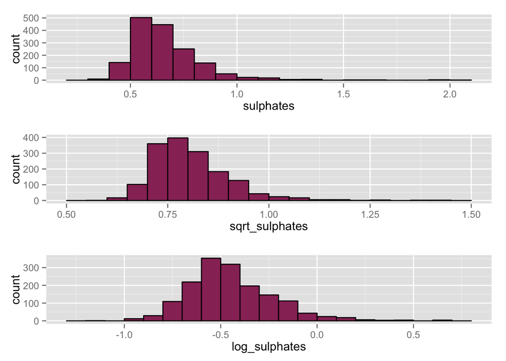

The square root helps a little bit, the log scale is more normal distributed

# Bivariate Plots Section

### Bivariate Plots Selection

The list of the top 4 factor that is correlated with the wine quality with a correlation value greater than 0.2

| Property | r-value |
| --- | --- |
| alcohol | 0.476 |
| volatile.acidity | -0.391 |
| sulphates | 0.251 |
| citric.acid | 0.226 |

### Bivariate Analysis

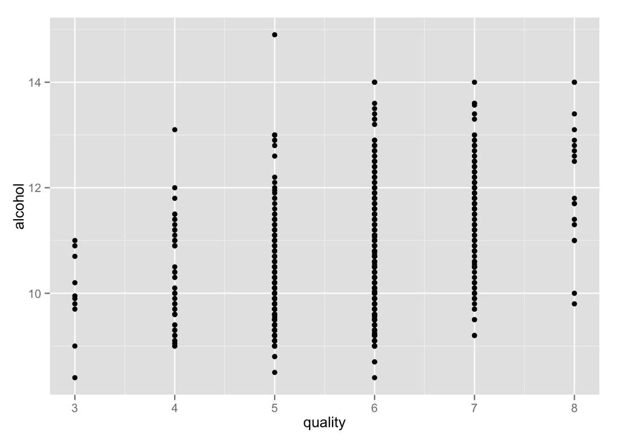

The original plot looks over plotted, so we add alpha value and 0.1, 0.5 and 0.9 percentile line to show the general trends.

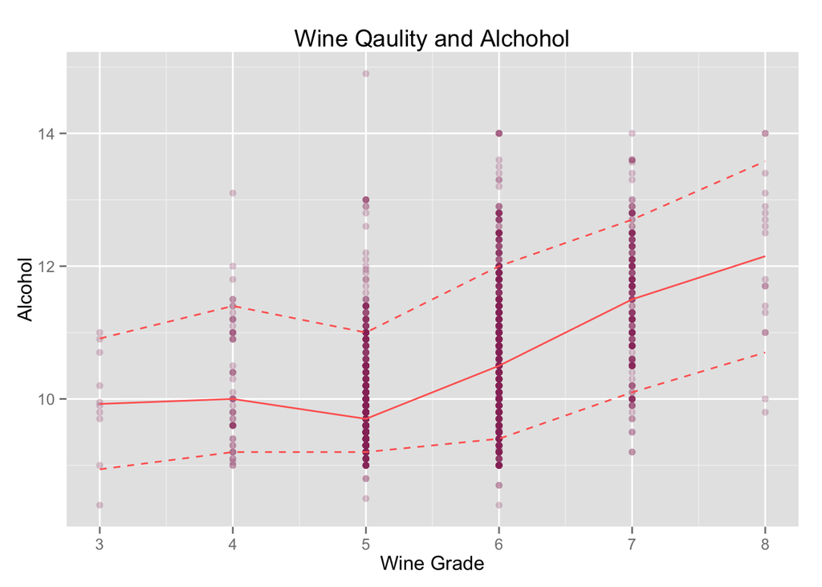

In this plot the trend of increasing wind quality with the increasing of alcohol content can be clearly observed.

### Transforming Wine Quality into Categorical Data

Since the wine quality are desecrate value, we can transform it from numerical data to categorical data. And there, box plot can be used to represent the data.

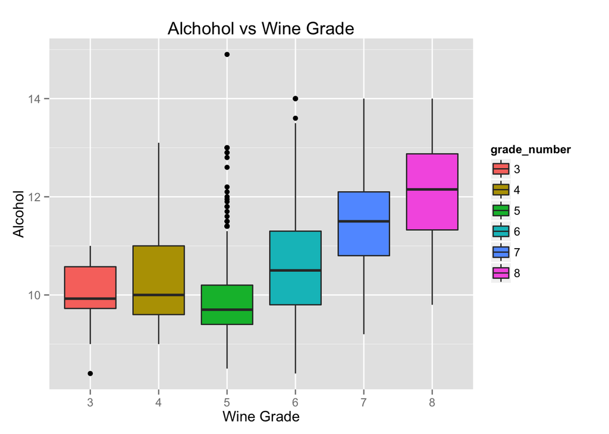

In generally, higher quality wine have higher alcholol content

Similar we did the analysis on the other 3 factors

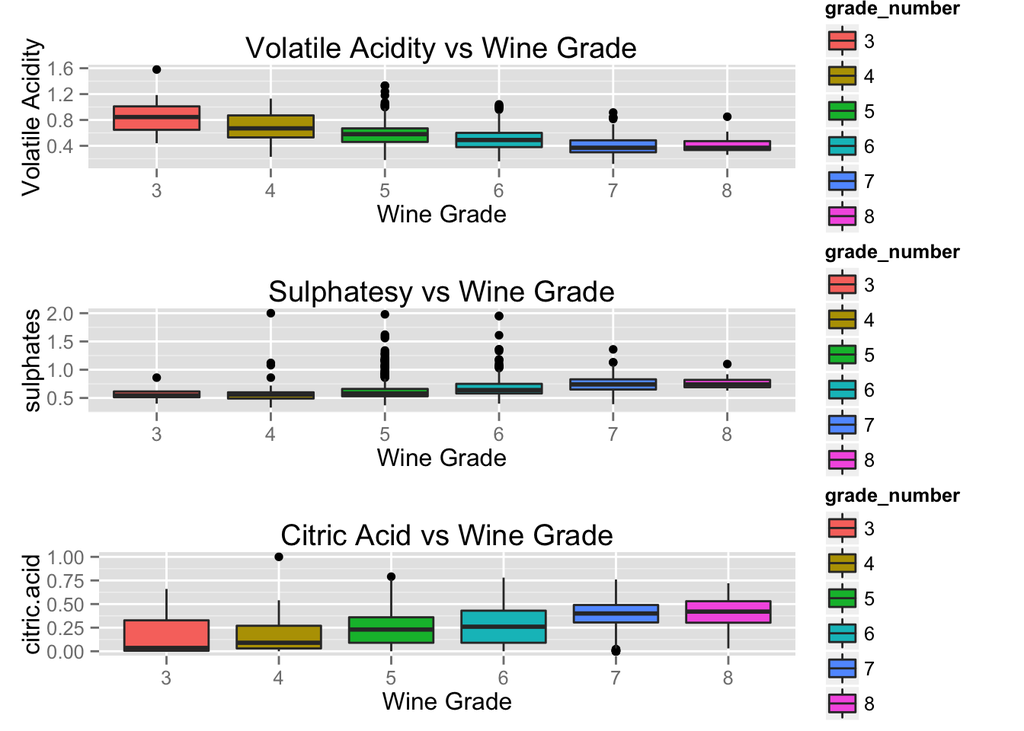

### Bivariate Analysis

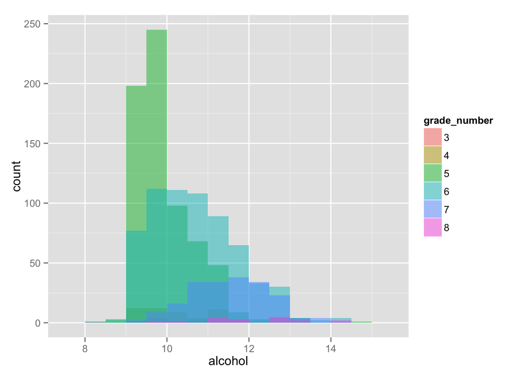

Notes that the data size is not normailize

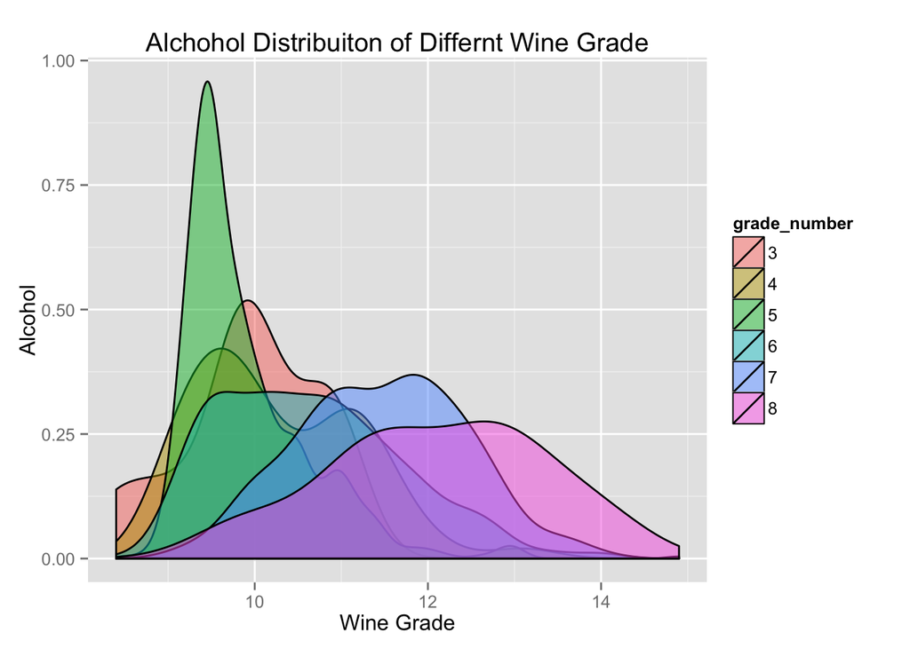

The plot looks a little busy. We ground 2 grade together

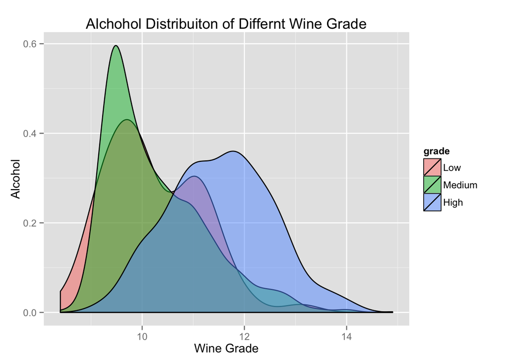

this looks better

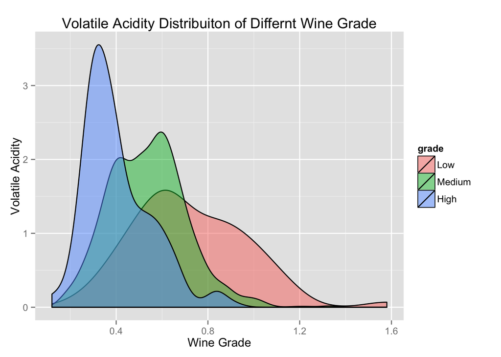

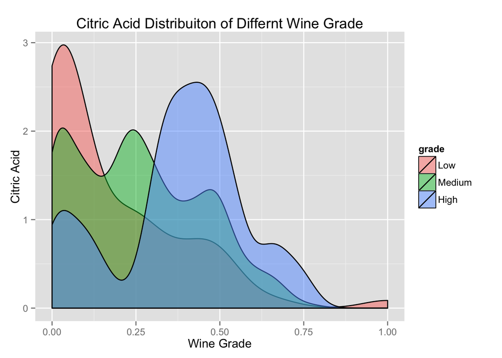

skewed, we use log

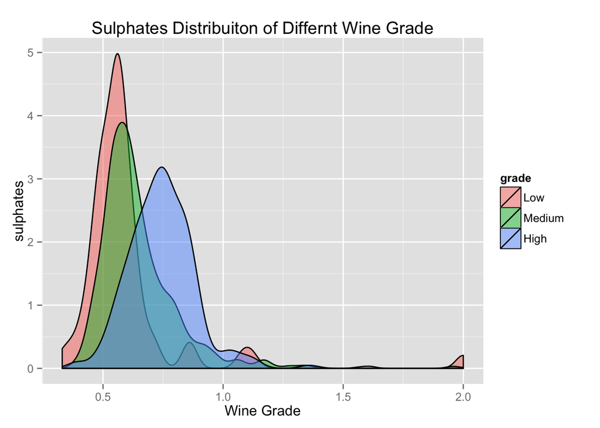

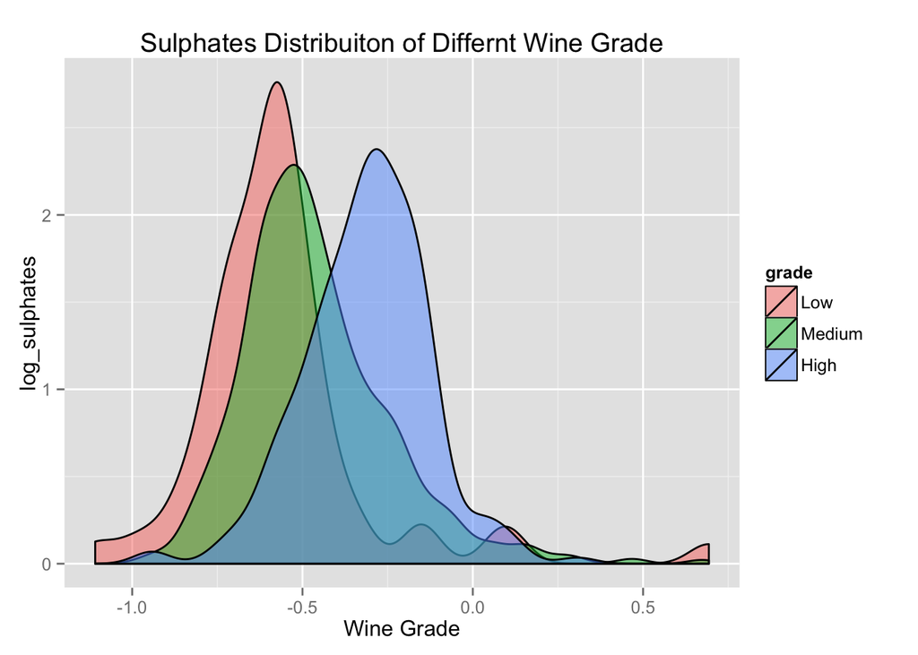